# Fansler et al., Nature Communications, Suppl. Figure 6

Sibylle Mitschka

Loading of R packages (not all may be required for this code section).

```r
library(tidyverse)
library(broom)
library(Biostrings)
library(ggpubr)
library(rtracklayer)
library(org.Hs.eg.db)
library(RColorBrewer)
library(biomaRt)
library(GenomicFeatures)
library(BSgenome)
library(GeneOverlap)
library(pheatmap)
library(biomaRt)
library(plyranges)
library(ggrepel)
library(writexl)
library(gridExtra)
library(readxl)
```

Load Supplentary Data 6

```r
sum_clus <- read_xlsx("Table_outputs/Supplementary_Data_6.xlsx") %>%
  dplyr::rename(target_gene = Gene_symbol)
```

These are the top regulators of APA and IPA (shown in Suppl. Fig 6a) in the Perturb-seq data set.

```r
sum_clus %>%
  slice_max(a_dwui, n=10)
```

| target_gene | Ensembl_ID | sgID_AB | n_cells | Cluster_id | Cluster_name | a_dwui | a_dipa |
| --- | --- | --- | --- | --- | --- | --- | --- |
| FIP1L1 | ENSG00000145216 | FIP1L1_+_54243867.23-P1P2\|FIP1L1_-_54244090.23-P1P2 | 21 | NA | NA | 0.03278754 | -0.0273151131 |
| RBBP6 | ENSG00000122257 | RBBP6_+_24550948.23-P1P2\|RBBP6_+_24550884.23-P1P2 | 86 | 16 | Transcription regulation II | 0.03179962 | -0.0177508074 |
| RBM25 | ENSG00000119707 | RBM25_+_73525283.23-P1P2\|RBM25_-_73525471.23-P1P2 | 70 | 16 | Transcription regulation II | 0.02893938 | 0.0128248733 |
| RTF1 | ENSG00000137815 | RTF1_-_41709376.23-P1P2\|RTF1_-_41709401.23-P1P2 | 62 | 17 | CPSF, CSTF and PAF complex | 0.02840182 | 0.0079708293 |
| SARS | ENSG00000031698 | SARS_+_109756585.23-P1P2\|SARS_-_109756603.23-P1P2 | 28 | NA | NA | 0.02828151 | -0.0011486480 |
| SRSF7 | ENSG00000115875 | SRSF7_+_38978481.23-P1P2\|SRSF7_-_38978026.23-P1P2 | 118 | 16 | Transcription regulation II | 0.02697478 | -0.0006594964 |
| PCF11 | ENSG00000165494 | PCF11_-_82868415.23-P1P2\|PCF11_-_82868190.23-P1P2 | 499 | 16 | Transcription regulation II | 0.02630787 | -0.0169586557 |
| PRPF40A | ENSG00000196504 | PRPF40A_+_153573726.23-P1P2\|PRPF40A_+_153573902.23-P1P2 | 118 | 16 | Transcription regulation II | 0.02460164 | 0.0158672853 |
| POT1 | ENSG00000128513 | POT1_+_124569865.23-P1P2\|POT1_-_124569870.23-P1P2 | 5 | NA | NA | 0.02402037 | -0.0132170080 |
| EXOSC5 | ENSG00000077348 | EXOSC5_+_41903223.23-P1P2\|EXOSC5_-_41903252.23-P1P2 | 41 | 18 | Nuclear exosome | 0.02262918 | 0.0066094540 |

```r
sum_clus %>%
  slice_max(a_dipa, n=10)
```

| target_gene | Ensembl_ID | sgID_AB | n_cells | Cluster_id | Cluster_name | a_dwui | a_dipa |
| --- | --- | --- | --- | --- | --- | --- | --- |
| DBR1 | ENSG00000138231 | DBR1_+_137893744.23-P1P2\|DBR1_+_137893673.23-P1P2 | 98 | 12 | mRNA splicing II | 0.007974722 | 0.03977037 |
| SNRPD2 | ENSG00000125743 | SNRPD2_+_46195119.23-P1P2\|SNRPD2_+_46195138.23-P1P2 | 19 | NA | NA | 0.007553801 | 0.03879625 |
| NUDT21 | ENSG00000167005 | NUDT21_+_56485197.23-P1P2\|NUDT21_-_56485228.23-P1P2 | 67 | 1 | CFIm complex | -0.145192203 | 0.03096486 |
| DDX41 | ENSG00000183258 | DDX41_+_176943914.23-P1P2\|DDX41_+_176943922.23-P1P2 | 292 | 12 | mRNA splicing II | 0.005629097 | 0.03010629 |
| PAF1 | ENSG00000006712 | PAF1_+_39881751.23-P1P2\|PAF1_-_39881702.23-P1P2 | 238 | 17 | CPSF, CSTF and PAF complex | 0.017623724 | 0.02945986 |
| CPSF6 | ENSG00000111605 | CPSF6_+_69633592.23-P1P2\|CPSF6_+_69633482.23-P1P2 | 50 | 1 | CFIm complex | -0.124180261 | 0.02864262 |
| OGFOD1 | ENSG00000087263 | OGFOD1_-_56485723.23-P1P2\|OGFOD1_+_56485469.23-P1P2 | 114 | 1 | CFIm complex | -0.114608406 | 0.02551663 |
| PLRG1 | ENSG00000171566 | PLRG1_+_155471467.23-P1P2\|PLRG1_+_155471521.23-P1P2 | 94 | 12 | mRNA splicing II | -0.003301267 | 0.02506717 |
| LSM5 | ENSG00000106355 | LSM5_-_32529957.23-P1\|LSM5_-_32529937.23-P1 | 42 | 11 | mRNA splicing I | -0.002567068 | 0.02502223 |
| TTC27 | ENSG00000018699 | TTC27_+_32853190.23-P1P2\|TTC27_+_32853193.23-P1P2 | 89 | 11 | mRNA splicing I | -0.008585502 | 0.02422878 |

```r
sum_clus %>%
  slice_min(a_dwui, n=10)
```

| target_gene | Ensembl_ID | sgID_AB | n_cells | Cluster_id | Cluster_name | a_dwui | a_dipa |
| --- | --- | --- | --- | --- | --- | --- | --- |
| NUDT21 | ENSG00000167005 | NUDT21_+_56485197.23-P1P2\|NUDT21_-_56485228.23-P1P2 | 67 | 1 | CFIm complex | -0.14519220 | 0.0309648590 |
| CPSF6 | ENSG00000111605 | CPSF6_+_69633592.23-P1P2\|CPSF6_+_69633482.23-P1P2 | 50 | 1 | CFIm complex | -0.12418026 | 0.0286426158 |
| OGFOD1 | ENSG00000087263 | OGFOD1_-_56485723.23-P1P2\|OGFOD1_+_56485469.23-P1P2 | 114 | 1 | CFIm complex | -0.11460841 | 0.0255166285 |
| THOC2 | ENSG00000125676 | THOC2_+_122866836.23-P1P2\|THOC2_-_122866493.23-P1P2 | 190 | 1 | CFIm complex | -0.03568003 | -0.0110791299 |
| THOC3 | ENSG00000051596 | THOC3_-_175395258.23-P1P2\|THOC3_-_175395273.23-P1P2 | 147 | 1 | CFIm complex | -0.03161312 | -0.0086762116 |
| THOC5 | ENSG00000100296 | THOC5_-_29949679.23-P1P2\|THOC5_-_29949705.23-P1P2 | 32 | 2 | mRNA export | -0.02616508 | -0.0005787462 |
| THOC1 | ENSG00000079134 | THOC1_-_268006.23-P1P2\|THOC1_-_268026.23-P1P2 | 38 | 1 | CFIm complex | -0.02604475 | -0.0018632584 |
| SEM1 | ENSG00000127922 | SHFM1_+_96339147.23-P1P2\|SHFM1_+_96339150.23-P1P2 | 88 | 2 | mRNA export | -0.02168078 | -0.0032754243 |
| TCERG1 | ENSG00000113649 | TCERG1_-_145826915.23-P1P2\|TCERG1_-_145826962.23-P1P2 | 105 | 2 | mRNA export | -0.02091348 | 0.0024572211 |
| GLE1 | ENSG00000119392 | GLE1_-_131267022.23-P1P2\|GLE1_+_131267242.23-P1P2 | 57 | 2 | mRNA export | -0.02083346 | 0.0011633737 |

```r
sum_clus %>%
  slice_min(a_dipa, n=10)
```

| target_gene | Ensembl_ID | sgID_AB | n_cells | Cluster_id | Cluster_name | a_dwui | a_dipa |
| --- | --- | --- | --- | --- | --- | --- | --- |
| RPL7A | ENSG00000148303 | RPL7A_-_136215123.23-P1P2\|RPL7A_+_136215092.23-P1P2 | 10 | NA | NA | 0.0208414915 | -0.03592262 |
| XRN1 | ENSG00000114127 | XRN1_+_142166856.23-P1P2\|XRN1_-_142166648.23-P1P2 | 10 | NA | NA | -0.0006270308 | -0.03254512 |
| CPSF2 | ENSG00000165934 | CPSF2_-_92588375.23-P1P2\|CPSF2_+_92588358.23-P1P2 | 20 | NA | NA | 0.0096540347 | -0.02825526 |
| FIP1L1 | ENSG00000145216 | FIP1L1_+_54243867.23-P1P2\|FIP1L1_-_54244090.23-P1P2 | 21 | NA | NA | 0.0327875405 | -0.02731511 |
| CSTF1 | ENSG00000101138 | CSTF1_+_54967480.23-P1P2\|CSTF1_-_54967707.23-P1P2 | 141 | 17 | CPSF, CSTF and PAF complex | 0.0107591567 | -0.02564137 |
| CPSF4 | ENSG00000160917 | CPSF4_-_99036611.23-P1P2\|CPSF4_-_99036577.23-P1P2 | 59 | 17 | CPSF, CSTF and PAF complex | 0.0182004170 | -0.02538547 |
| CSTF3 | ENSG00000176102 | CSTF3_+_33183038.23-P1P2\|CSTF3_-_33182802.23-P1P2 | 66 | 17 | CPSF, CSTF and PAF complex | 0.0148275766 | -0.02485290 |
| TAF12 | ENSG00000120656 | TAF12_+_28969568.23-P1P2\|TAF12_+_28969521.23-P1P2 | 67 | 16 | Transcription regulation II | 0.0196071350 | -0.02241381 |
| UBA52 | ENSG00000221983 | UBA52_-_18682701.23-P1\|UBA52_+_18682887.23-P1 | 28 | NA | NA | 0.0136834448 | -0.02183881 |
| CPSF3 | ENSG00000119203 | CPSF3_+_9564024.23-P1P2\|CPSF3_+_9563875.23-P1P2 | 627 | 17 | CPSF, CSTF and PAF complex | 0.0196856093 | -0.02124710 |

In Suppl. Figure 6d-h we show overview plots for global APA and IPA changes caused by perturbations of known components of cleavage factor complexes. The sets of genes included in each complex have been selected based on a comprehensive literature search. Please note that some of the genes that are part of a known sub-complex may not be represented in this Perturb-seq data set (e.g. CSTF2 and LEO1).

Here we are using a summary of global average deviations of WUI and IPA for each perturbation, called a_dwui and a_dipa, respectively. Theses data are provided as Supplementary Data 6.

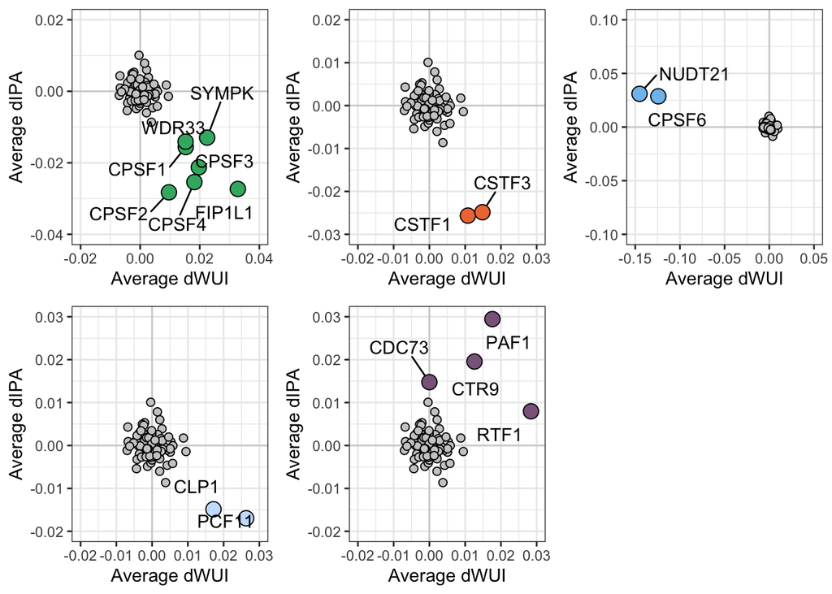

```r
gene_set_cpsf <- c("non-targeting","CPSF1","CPSF2","CPSF3","CPSF4","FIP1L1","SYMPK", "WDR33")
gene_set_cfim <- c("non-targeting","NUDT21","CPSF6")
gene_set_cstf <- c("non-targeting","CSTF1","CSTF2","CSTF3","CSTF4")
gene_set_cfiim <- c("non-targeting","PCF11","CLP1")
gene_set_paf <- c("non-targeting","PAF1","CTR9","RTF1","LEO1","CDC73", "SKIC8")


cfim <- sum_clus %>%
  filter(target_gene %in% gene_set_cfim) %>%
  group_by(sgID_AB, target_gene) %>%
  ggplot(aes(x=a_dwui, y= a_dipa, fill=target_gene, label=target_gene)) +
          geom_hline(yintercept=0, col="lightgrey") +
          geom_vline(xintercept=0, col="lightgrey") +
          geom_point(aes(size=target_gene), pch=21, stroke=0.5) +
          coord_cartesian(xlim=c(-0.15,0.05),ylim=c(-0.1,0.1)) +
          scale_fill_manual(breaks=gene_set_cfim, values=c("grey80", rep("skyblue2",6))) +
          scale_size_manual(breaks=gene_set_cfim, values=c(2, 4, 4)) +
          geom_text_repel(aes(label= ifelse(target_gene=="non-targeting",'',
                        as.character(target_gene))),
                        box.padding= 0.6,
                        point.padding = 0.5) +
          guides(fill = FALSE, size=FALSE) +
          xlab("Average dWUI") +
          ylab("Average dIPA") +
          theme_bw()
cpsf <- sum_clus %>%
  filter(target_gene %in% gene_set_cpsf) %>%
  group_by(sgID_AB, target_gene) %>%
  ggplot(aes(x=a_dwui, y= a_dipa, fill=target_gene, label=target_gene)) +
          geom_hline(yintercept=0, col="lightgrey")+
          geom_vline(xintercept=0, col="lightgrey")+
          geom_point(aes(size=target_gene), pch=21, stroke=0.5)+
          coord_cartesian(xlim=c(-0.02,0.04), ylim=c(-0.04,0.02)) +
          scale_fill_manual(breaks=gene_set_cpsf,
                            values=c("grey80", rep("mediumseagreen",7))) +
          scale_size_manual(breaks=gene_set_cpsf,
                    values=c(2, rep(4,7))) +
          geom_text_repel(aes(label=ifelse(target_gene=="non-targeting",'',
                    as.character(target_gene))),
                    box.padding= 0.6,
                    point.padding = 0.5) +
          guides(fill = FALSE, size=FALSE) +
          xlab("Average dWUI")+
          ylab("Average dIPA")+
          theme_bw()


cstf <- sum_clus %>%
  filter(target_gene %in% gene_set_cstf) %>%
  group_by(sgID_AB, target_gene) %>%
  ggplot(aes(x=a_dwui, y= a_dipa, fill=target_gene, label=target_gene)) +
          geom_hline(yintercept=0, col="lightgrey")+
          geom_vline(xintercept=0, col="lightgrey")+
          geom_point(aes(size=target_gene), pch=21, stroke=0.5)+
          coord_cartesian(xlim=c(-0.02,0.03), ylim=c(-0.03,0.02))+
          scale_fill_manual(breaks=gene_set_cstf, values=c("grey80", rep("sienna2", 4))) +
          scale_size_manual(breaks=gene_set_cstf, values=c(2, rep(4,4))) +
          geom_text_repel(aes(label=ifelse(target_gene=="non-targeting",'',
                    as.character(target_gene))),
                    box.padding= 0.6,
                    point.padding = 0.5) +
          guides(fill = FALSE, size=FALSE) +
          xlab("Average dWUI")+
          ylab("Average dIPA")+
          theme_bw()

cfiim <- sum_clus %>%
  filter(target_gene %in% gene_set_cfiim) %>%
  group_by(sgID_AB, target_gene) %>%
  ggplot(aes(x=a_dwui, y= a_dipa, fill=target_gene, label=target_gene)) +
          geom_hline(yintercept=0, col="lightgrey")+
          geom_vline(xintercept=0, col="lightgrey")+
          geom_point(aes(size=target_gene), pch=21, stroke=0.5)+
          coord_cartesian(xlim=c(-0.02,0.03), ylim=c(-0.02,0.03))+
          scale_fill_manual(breaks=gene_set_cfiim,
                            values=c("grey80", rep("lightsteelblue1", 2))) +
          scale_size_manual(breaks=gene_set_cfiim,
                    values=c(2, rep(4,2))) +
          geom_text_repel(aes(label=ifelse(target_gene=="non-targeting",'',
                    as.character(target_gene))),
                    box.padding= 0.6,
                    point.padding = 0.5) +
          guides(fill = FALSE, size=FALSE) +
          xlab("Average dWUI")+
          ylab("Average dIPA")+
          theme_bw()

paf <- sum_clus %>%
  filter(target_gene %in% gene_set_paf) %>%
  group_by(sgID_AB, target_gene) %>%
  ggplot(aes(x=a_dwui, y= a_dipa, fill=target_gene, label=target_gene)) +
          geom_hline(yintercept=0, col="lightgrey")+
          geom_vline(xintercept=0, col="lightgrey")+
          geom_point(aes(size=target_gene), pch=21, stroke=0.5)+
          coord_cartesian(xlim=c(-0.02,0.03), ylim=c(-0.02,0.03))+
          scale_fill_manual(breaks=gene_set_paf, values=c("grey80", rep("plum4", 6))) +
          scale_size_manual(breaks=gene_set_paf,
                    values=c(2, rep(4,6))) +
          geom_text_repel(aes(label=ifelse(target_gene=="non-targeting",'',
                    as.character(target_gene))),
                    box.padding= 0.6,
                    point.padding = 0.5) +
          guides(fill = FALSE, size=FALSE) +
          xlab("Average dWUI")+
          ylab("Average dIPA")+
          theme_bw()


Sup_Fig6dh <- grid.arrange(cpsf, cstf, cfim, cfiim, paf, ncol=3, nrow=2)
```

```r
ggsave("Figure_outputs/Sup_Fig6d-h.pdf", Sup_Fig6dh, height=8, width=12)
```

Reviewer question: “When GE and UTR isoform were compared between different samples, the two were often regulated in different set of genes. Have the authors checked whether GE was more likely changed for single UTR genes, in particular for the perturbation of core CPA machinery?”